Created by: Marco Hafid - 22-620-546 Matus Kubla - 23-604-382

Disclaimer: Due to the running time of the code we reduced the sample size for the final version.

Importing libraries

```r
suppressWarnings({
  library(class)
  library(pracma)
  library(ggplot2)
})
```

Question 1:

In the first question, we create a k-Nearest Neighbors algorithm that will aim to accurately classify simulated datasest into classes. We train the model on a generated training dataset and test its accuracy 50 (arbitrary number) of additional, randomly generated samples. Our estimation function takes both the hyperparameter k (number of nearest neighbors to consider) and the p-norm as parameters, allowing to flexibly test the model’s performance on various ‘settings’. In our case, we default the p-norm to 2, indicating to use the Euclidean distance.

The model will be tested with k values of 3 and 5, but can easily be replicated with different values. We opted for these values to strike a balance between robustness to noise (to avoid overfitting), precision, and computational complexity. When simulating datasets, we use three, increasing feature dimensions. Similarly, we also alternate between various sample sizes (100, 200, 300 (chosen arbitrarily)), and provide an analysis of results, including both accuracy and runtime for all possible combinations of parameters.

Defining the functions

```r
# Create function to calculate the distance of two points
calculate_distance <- function(point1, point2, p = 2) {
  sum(abs(point1 - point2)^p)^(1/p)
}

# Create function to predict the class of a test point using kNN
knn_predict <- function(train_data, train_labels, test_point, k = 3, p = 2) {
  distances <- apply(train_data, 1, function(train_point) calculate_distance(train_point, test_point, p))
  nearest_neighbors <- order(distances)[1:k]
  nearest_labels <- train_labels[nearest_neighbors]
  predicted_class <- as.numeric(names(sort(table(nearest_labels), decreasing = TRUE)[1]))
  return(predicted_class)
}

# Create function to evaluate the classification accuracy
evaluate_accuracy <- function(train_data, train_labels, test_data, test_labels, k = 3, p = 2) {
  predictions <- sapply(1:nrow(test_data), function(i) knn_predict(train_data, train_labels, test_data[i, ], k, p))
  accuracy <- sum(predictions == test_labels) / length(test_labels)
  return(accuracy)
}
```

Generating the random dataset and calling the functions

```r
# Create function to simulate training and test datasets
simulate_datasets <- function(n_samples, n_test_samples, dim) {
  set.seed(123)
  train_data <- matrix(runif(n_samples * dim), ncol = dim)
  train_labels <- sample(c(0, 1), n_samples, replace = TRUE)

  test_data <- matrix(runif(n_test_samples * dim), ncol = dim)
  test_labels <- sample(c(0, 1), n_test_samples, replace = TRUE)

  return(list(train_data = train_data, train_labels = train_labels, test_data = test_data, test_labels = test_labels))
}

# Create function to evaluate the classification accuracy for different sample sizes
evaluate_accuracy_with_sample_sizes <- function(dim, k_values, sample_sizes, n_test_samples) {
  for (n_samples in sample_sizes) {
    cat("Sample Size:", n_samples, "\n")

    # Simulate datasets
    datasets <- simulate_datasets(n_samples, n_test_samples, dim)

    for (k in k_values) {
      cat("Dimensions:", dim, "\n")
      cat("k:", k, "\n")

      # Measure the runtime
      start_time <- Sys.time()

      # Evaluate the accuracy
      accuracy <- evaluate_accuracy(datasets$train_data, datasets$train_labels, datasets$test_data, datasets$test_labels, k)

      # Print results
      cat("Accuracy:", accuracy, "\n")
      cat("Runtime:", round(difftime(Sys.time(), start_time, units = "secs"), 2), "seconds\n\n")
    }
  }
}

# Specify different sample sizes to test
sample_sizes <- c(100, 200, 300)

# Specify other parameters
dimensions <- c(10, 50, 1000)
k_values <- c(3, 5)

# Set the number of test samples
n_test_samples <- 50

# Testing the kNN algorithm with different sample sizes, feature dimensions, and k-values
for (dim in dimensions) {
  evaluate_accuracy_with_sample_sizes(dim, k_values, sample_sizes, n_test_samples)
}
```

```
## Sample Size: 100
## Dimensions: 10
## k: 3
## Accuracy: 0.5
## Runtime: 0.03 seconds
##
## Dimensions: 10
## k: 5
## Accuracy: 0.4
## Runtime: 0.03 seconds
##
## Sample Size: 200
## Dimensions: 10
## k: 3
## Accuracy: 0.52
## Runtime: 0.03 seconds
##
## Dimensions: 10
## k: 5
## Accuracy: 0.5
## Runtime: 0.03 seconds
##
## Sample Size: 300
## Dimensions: 10
## k: 3
## Accuracy: 0.56
## Runtime: 0.04 seconds
##
## Dimensions: 10
## k: 5
## Accuracy: 0.5
## Runtime: 0.04 seconds
##
## Sample Size: 100
## Dimensions: 50
## k: 3
## Accuracy: 0.56
## Runtime: 0.02 seconds
##
## Dimensions: 50
```

[output cut: 43 more lines]

```
## Dimensions: 1000
## k: 5
## Accuracy: 0.52
## Runtime: 0.21 seconds
##
## Sample Size: 300
## Dimensions: 1000
## k: 3
## Accuracy: 0.5
## Runtime: 0.34 seconds
##
## Dimensions: 1000
## k: 5
## Accuracy: 0.54
## Runtime: 0.34 seconds
```

```r
# # Create function to plot accuracy and runtime
# plot_accuracy_runtime <- function(results) {
#   results$Runtime <- as.numeric(as.character(results$Runtime)) # Convert Runtime to numeric
#
#   ggplot(results, aes(x = Sample_Size, y = Accuracy, color = factor(k), group = factor(k))) +
#     geom_line() +
#     geom_point() +
#     facet_grid(Dimensions ~ .) +
#     labs(title = "Accuracy vs. Sample Size by k and Dimension",
#          x = "Sample Size",
#          y = "Accuracy",
#          color = "k") +
#     theme_minimal() +
#     theme(legend.position = "bottom") +
#     scale_color_discrete(name = "k") +
#     geom_line(aes(y = Runtime / max(Runtime) * max(Accuracy) * 0.95), linetype = "dashed", color = "black") +
#     geom_point(aes(y = Runtime / max(Runtime) * max(Accuracy) * 0.95), color = "black", shape = 1) +
#     geom_text(aes(label = paste0(Runtime, "s"), y = Runtime / max(Runtime) * max(Accuracy) * 0.95), vjust = -0.5, hjust = -0.5, size = 3)
# }
#
# # Evaluate accuracy and runtime
# results <- data.frame()
# for (dim in dimensions) {
#   results <- rbind(results, evaluate_accuracy_with_sample_sizes(dim, k_values, sample_sizes, n_test_samples))
# }
#
# # Plot accuracy and runtime
# plot_accuracy_runtime(results)
```

Looking at the results, we see a comparable accuracy across sample sizes, ranging from 0,4 to 0,6. When assessing the effect of different values for the k paramater, we notice heterogeneous impacts across sample sizes. While increasing k leads to worse accuracy for all sample sizes when the feature dimension is small (10), the opposite is true when we increasing the dimension to 1000. The impact when considering the feature dimension of 50 proved to not be uniform across sample sizes. Note that, while an increased number of features should technically lead to more accurate decisions (we have more information about each data point), including way too many features can lead to overfitting, which leads to worse out of sample predictions and hence lower accuracy. This may be an explanation why, when using 1000 features, acccuracy was on average worse than for the 50 feature case, which proved to yield the highest accuracy. Finally, when looking at runtime, we observe a clear upward trend as the feature dimension and sample size increases. This makes sense, as both of these factors have a direct impact on the computational requirements of the algorithm. As the KNN algorithm needs to calculate distances between individual observations, this becomes increasingly more complicated as the number of features (and hence the dimensionality of the data) increases. Similarly, a bigger sample size clearly involves more calculations to be made, leading to higher runtime. This was reflected in our measurements, with the model (s = 300 ; d = 1000) taking more than 10x as much time as the simple (s=100 ; d =10) case. That said, while the latter applies, individual runtimes are influenced by other factors unique to the computer at that specific time, and may not always accurately reflect the increase in computational complexity beyween the different cases.

Compare our function to the inbuilt class package

```r
# Create function to perform kNN using the 'class' package
knn_class_package <- function(train_data, train_labels, test_data, k = 3) {
  predictions <- knn(train_data, test_data, train_labels, k = k)
  return(predictions)
}

# Create function to evaluate the classification accuracy using the 'class' package
evaluate_accuracy_class_package <- function(train_data, train_labels, test_data, test_labels, k = 3) {
  predictions <- knn_class_package(train_data, train_labels, test_data, k)
  accuracy <- sum(predictions == test_labels) / length(test_labels)
  return(accuracy)
}

# Create function to evaluate both custom kNN and 'class' package for comparison
compare_knn_implementations <- function(dim, k_values, sample_sizes) {
  for (n_samples in sample_sizes) {
    cat("Sample Size:", n_samples, "\n")

    # Simulate datasets
    datasets <- simulate_datasets(n_samples, n_test_samples, dim)

    for (k in k_values) {
      cat("Dimensions:", dim, "\n")
      cat("k:", k, "\n")

      # Measure the runtime and evaluate accuracy for custom kNN
      start_time_custom <- Sys.time()
      accuracy_custom <- evaluate_accuracy(datasets$train_data, datasets$train_labels, datasets$test_data, datasets$test_labels, k)
      cat("Custom kNN Accuracy:", accuracy_custom, "\n")
      cat("Custom kNN Runtime:", round(difftime(Sys.time(), start_time_custom, units = "secs"), 2), "seconds\n")

      # Evaluate accuracy for 'class' package kNN
      start_time_class <- Sys.time()
      accuracy_class <- evaluate_accuracy_class_package(datasets$train_data, datasets$train_labels, datasets$test_data, datasets$test_labels, k)
      cat("'class' Package kNN Accuracy:", accuracy_class, "\n")
      cat("'class' Package kNN Runtime:", round(difftime(Sys.time(), start_time_class, units = "secs"), 2), "seconds\n\n")
    }
  }
}

# Specify different sample sizes to test
sample_sizes <- c(100, 200, 300)

# Specify other parameters
dimensions <- c(10, 50, 1000)
k_values <- c(3, 5)

# Testing both custom kNN and 'class' package with different sample sizes, feature dimensions, and k-values
for (dim in dimensions) {
  compare_knn_implementations(dim, k_values, sample_sizes)
}
```

```
## Sample Size: 100
## Dimensions: 10
## k: 3
## Custom kNN Accuracy: 0.5
## Custom kNN Runtime: 0.02 seconds
## 'class' Package kNN Accuracy: 0.5
## 'class' Package kNN Runtime: 0 seconds
##
## Dimensions: 10
## k: 5
## Custom kNN Accuracy: 0.4
## Custom kNN Runtime: 0.02 seconds
## 'class' Package kNN Accuracy: 0.4
## 'class' Package kNN Runtime: 0 seconds
##
## Sample Size: 200
## Dimensions: 10
## k: 3
## Custom kNN Accuracy: 0.52
## Custom kNN Runtime: 0.03 seconds
## 'class' Package kNN Accuracy: 0.52
## 'class' Package kNN Runtime: 0 seconds
##
## Dimensions: 10
## k: 5
## Custom kNN Accuracy: 0.5
## Custom kNN Runtime: 0.03 seconds
## 'class' Package kNN Accuracy: 0.5
## 'class' Package kNN Runtime: 0 seconds
##
## Sample Size: 300
## Dimensions: 10
## k: 3
## Custom kNN Accuracy: 0.56
## Custom kNN Runtime: 0.05 seconds
## 'class' Package kNN Accuracy: 0.56
## 'class' Package kNN Runtime: 0 seconds
##
## Dimensions: 10
## k: 5
```

[output cut: 79 more lines]

```
##
## Sample Size: 300
## Dimensions: 1000
## k: 3
## Custom kNN Accuracy: 0.5
## Custom kNN Runtime: 0.36 seconds
## 'class' Package kNN Accuracy: 0.5
## 'class' Package kNN Runtime: 0.02 seconds
##
## Dimensions: 1000
## k: 5
## Custom kNN Accuracy: 0.54
## Custom kNN Runtime: 0.39 seconds
## 'class' Package kNN Accuracy: 0.54
## 'class' Package kNN Runtime: 0.02 seconds
```

Question 2 In the second exercise, we address the issue of computational complexity with high feature dimension by modifying the KNN algorithm. To do this, we generate a lower-dimensional orthonormal matrix to project high-dimensional feature vectors and dataset into a lower-dimensional space. This allows us to classify the feature vectors using k-nearest neighbours among the projected data, effectively reducing computational complexity. To do this, we use the built in function randortho from the pracma package.

In the second exercise, we address the issue of computational complexity with high feature dimension by modifying the KNN algorithm. To do this, we generate a lower-dimensional orthonormal matrix to project high-dimensional feature vectors and dataset into a lower-dimensional space. This allows us to classify the feature vectors using k-nearest neighbours among the projected data, effectively reducing computational complexity. To do this, we use the built in function randortho from the pracma package.

For our analysis, we explored the effects of different p-norms (mainly 1 (absolute-value) and 2 (Euclidean)). This is only a sample example, other norms could easily be implemented by changing the p-parameter. We also, included varying value for the k-hyperparameter, as well as alternating sample sizes. Similarly, we separate our results based on two possible values (can also be chosen), which assign the dimension to be reduced to.

```r
# Create function to generate a random orthonormal matrix
generate_random_orthonormal_matrix <- function(p, l) {
  U_full <- randortho(p)
  U <- U_full[1:l, ]  # Selecting the first l rows
  return(U)
}

knn_projected <- function(train_data, train_labels, test_data, k = 3, l = 5, p_norm = 2) {
  U <- generate_random_orthonormal_matrix(ncol(train_data), l)
  train_data_projected <- train_data %*% t(U)
  test_data_projected <- test_data %*% t(U)
  knn_predict <- function(train_data, train_labels, test_point, k, p_norm) {
    distances <- apply(train_data, 1, function(train_point) sum(abs(train_point - test_point)^p_norm)^(1/p_norm))
    nearest_neighbors <- order(distances)[1:k]
    nearest_labels <- train_labels[nearest_neighbors]
    predicted_class <- as.numeric(names(sort(table(nearest_labels), decreasing = TRUE)[1]))
    return(predicted_class)
  }
  predictions <- apply(test_data_projected, 1, function(test_point) knn_predict(train_data_projected, train_labels, test_point, k, p_norm))
  return(predictions)
}

evaluate_accuracy_projected <- function(train_data, train_labels, test_data, test_labels, k = 3, l = 5, p_norm = 2) {
  predictions <- knn_projected(train_data, train_labels, test_data, k, l, p_norm)
  accuracy <- sum(predictions == test_labels) / length(test_labels)
  return(accuracy)
}

# Initialize an empty dataframe to store results
results <- data.frame(n_samples = integer(),
                      dim = integer(),
                      l = integer(),
                      k = integer(),
                      p_norm = integer(),
                      accuracy = numeric())

compare_knn_projected <- function(dim, k_values, sample_sizes, l_values, p_norms) {
  for (n_samples in sample_sizes) {
    cat("Sample Size:", n_samples, "\n")
    set.seed(123)
    train_data <- matrix(runif(n_samples * dim), ncol = dim)
    train_labels <- sample(c(0, 1), n_samples, replace = TRUE)
    test_data <- matrix(runif(100 * dim), ncol = dim)  # Assuming n_test_samples is 100
    test_labels <- sample(c(0, 1), 100, replace = TRUE)
    for (l in l_values) {
      for (p_norm in p_norms) {
        for (k in k_values) {
          start_time_projected <- Sys.time()
          accuracy_projected <- evaluate_accuracy_projected(train_data, train_labels, test_data, test_labels, k, l, p_norm)
          runtime_projected <- round(difftime(Sys.time(), start_time_projected, units = "secs"), 2)
          cat("l:", l, "p-norm:", p_norm, "k:", k, "Accuracy:", accuracy_projected, "Runtime:", runtime_projected, "seconds\n")
          # Append the results to the dataframe
          results <<- rbind(results, data.frame(n_samples = n_samples,
                                                dim = dim,
                                                l = l,
                                                k = k,
                                                p_norm = p_norm,
                                                accuracy = accuracy_projected))
        }
      }
    }
  }
}

# Specify parameters
sample_sizes <- c(100, 200, 300)
dimensions <- c(10, 50, 1000)
k_values <- c(3, 5)
l_values <- c(2, 5)
p_norms <- c(1, 2)

# Run the experiments
for (dim in dimensions) {
  compare_knn_projected(dim, k_values, sample_sizes, l_values, p_norms)
}
```

```
## Sample Size: 100
## l: 2 p-norm: 1 k: 3 Accuracy: 0.51 Runtime: 0.05 seconds
## l: 2 p-norm: 1 k: 5 Accuracy: 0.45 Runtime: 0.04 seconds
## l: 2 p-norm: 2 k: 3 Accuracy: 0.54 Runtime: 0.03 seconds
## l: 2 p-norm: 2 k: 5 Accuracy: 0.5 Runtime: 0.04 seconds
## l: 5 p-norm: 1 k: 3 Accuracy: 0.46 Runtime: 0.04 seconds
## l: 5 p-norm: 1 k: 5 Accuracy: 0.56 Runtime: 0.04 seconds
## l: 5 p-norm: 2 k: 3 Accuracy: 0.49 Runtime: 0.03 seconds
## l: 5 p-norm: 2 k: 5 Accuracy: 0.47 Runtime: 0.04 seconds
## Sample Size: 200
## l: 2 p-norm: 1 k: 3 Accuracy: 0.53 Runtime: 0.05 seconds
## l: 2 p-norm: 1 k: 5 Accuracy: 0.47 Runtime: 0.05 seconds
## l: 2 p-norm: 2 k: 3 Accuracy: 0.52 Runtime: 0.05 seconds
## l: 2 p-norm: 2 k: 5 Accuracy: 0.47 Runtime: 0.05 seconds
## l: 5 p-norm: 1 k: 3 Accuracy: 0.53 Runtime: 0.06 seconds
## l: 5 p-norm: 1 k: 5 Accuracy: 0.5 Runtime: 0.05 seconds
## l: 5 p-norm: 2 k: 3 Accuracy: 0.48 Runtime: 0.05 seconds
## l: 5 p-norm: 2 k: 5 Accuracy: 0.51 Runtime: 0.05 seconds
## Sample Size: 300
## l: 2 p-norm: 1 k: 3 Accuracy: 0.46 Runtime: 0.07 seconds
## l: 2 p-norm: 1 k: 5 Accuracy: 0.42 Runtime: 0.07 seconds
## l: 2 p-norm: 2 k: 3 Accuracy: 0.51 Runtime: 0.07 seconds
## l: 2 p-norm: 2 k: 5 Accuracy: 0.5 Runtime: 0.07 seconds
## l: 5 p-norm: 1 k: 3 Accuracy: 0.52 Runtime: 0.07 seconds
## l: 5 p-norm: 1 k: 5 Accuracy: 0.47 Runtime: 0.08 seconds
## l: 5 p-norm: 2 k: 3 Accuracy: 0.4 Runtime: 0.07 seconds
## l: 5 p-norm: 2 k: 5 Accuracy: 0.47 Runtime: 0.07 seconds
## Sample Size: 100
## l: 2 p-norm: 1 k: 3 Accuracy: 0.54 Runtime: 0.04 seconds
## l: 2 p-norm: 1 k: 5 Accuracy: 0.56 Runtime: 0.03 seconds
## l: 2 p-norm: 2 k: 3 Accuracy: 0.48 Runtime: 0.04 seconds
## l: 2 p-norm: 2 k: 5 Accuracy: 0.57 Runtime: 0.04 seconds
## l: 5 p-norm: 1 k: 3 Accuracy: 0.41 Runtime: 0.04 seconds
## l: 5 p-norm: 1 k: 5 Accuracy: 0.43 Runtime: 0.04 seconds
## l: 5 p-norm: 2 k: 3 Accuracy: 0.45 Runtime: 0.04 seconds
## l: 5 p-norm: 2 k: 5 Accuracy: 0.54 Runtime: 0.04 seconds
## Sample Size: 200
## l: 2 p-norm: 1 k: 3 Accuracy: 0.51 Runtime: 0.05 seconds
## l: 2 p-norm: 1 k: 5 Accuracy: 0.57 Runtime: 0.06 seconds
## l: 2 p-norm: 2 k: 3 Accuracy: 0.49 Runtime: 0.07 seconds
```

[output cut: 26 more lines]

```
## l: 2 p-norm: 2 k: 3 Accuracy: 0.46 Runtime: 1.67 seconds
## l: 2 p-norm: 2 k: 5 Accuracy: 0.42 Runtime: 1.7 seconds
## l: 5 p-norm: 1 k: 3 Accuracy: 0.56 Runtime: 1.74 seconds
## l: 5 p-norm: 1 k: 5 Accuracy: 0.48 Runtime: 1.77 seconds
## l: 5 p-norm: 2 k: 3 Accuracy: 0.48 Runtime: 1.72 seconds
## l: 5 p-norm: 2 k: 5 Accuracy: 0.62 Runtime: 1.74 seconds
## Sample Size: 300
## l: 2 p-norm: 1 k: 3 Accuracy: 0.53 Runtime: 1.68 seconds
## l: 2 p-norm: 1 k: 5 Accuracy: 0.53 Runtime: 1.72 seconds
## l: 2 p-norm: 2 k: 3 Accuracy: 0.5 Runtime: 1.7 seconds
## l: 2 p-norm: 2 k: 5 Accuracy: 0.52 Runtime: 1.7 seconds
## l: 5 p-norm: 1 k: 3 Accuracy: 0.56 Runtime: 1.7 seconds
## l: 5 p-norm: 1 k: 5 Accuracy: 0.45 Runtime: 1.69 seconds
## l: 5 p-norm: 2 k: 3 Accuracy: 0.41 Runtime: 1.73 seconds
## l: 5 p-norm: 2 k: 5 Accuracy: 0.53 Runtime: 1.71 seconds
```

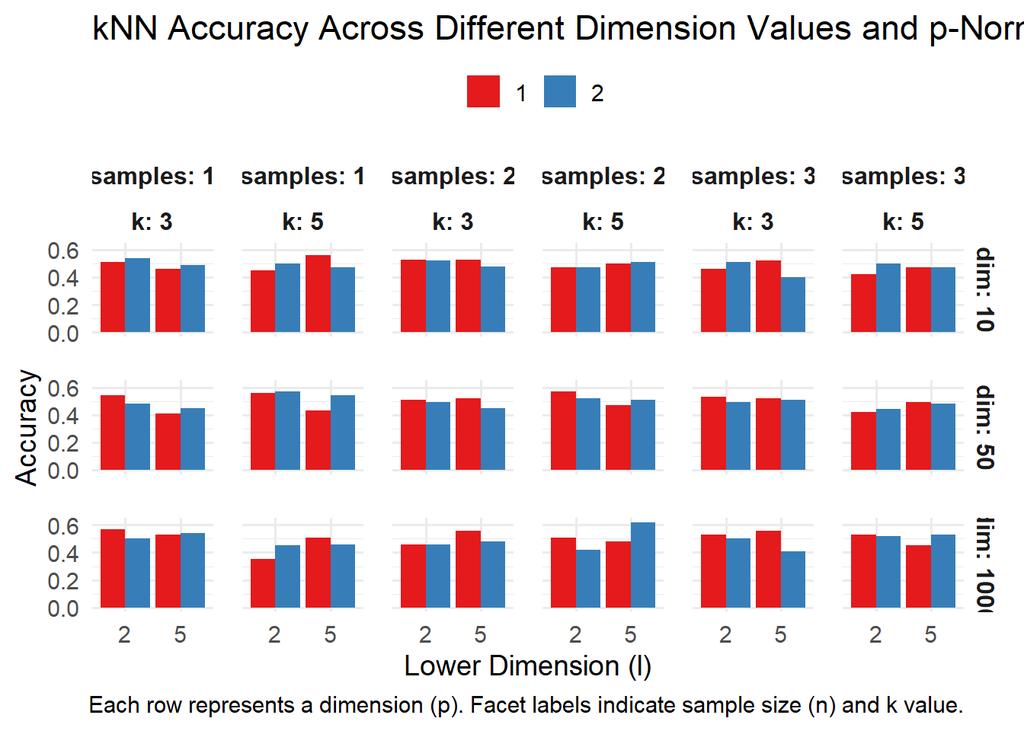

```r
theme_set(
  theme_minimal(base_size = 14) +
    theme(
      legend.position = "top",
      legend.title = element_blank(),
      strip.text = element_text(size = 12, face = "bold"),
      panel.spacing.x = unit(1, "lines"),
      panel.spacing.y = unit(1.5, "lines"),
      strip.placement = "outside"
    )
)

# Plotting the results with improved facet labels and organization
p <- ggplot(results, aes(x = factor(l), y = accuracy, fill = factor(p_norm))) +
  geom_bar(stat = "identity", position = "dodge") +
  facet_grid(dim ~ n_samples + k, scales = "free_x", space = "free_x", labeller = label_both) +
  scale_fill_brewer(palette = "Set1", name = "p-Norm") +
  labs(
    title = "kNN Accuracy Across Different Dimension Values and p-Norms",
    x = "Lower Dimension (l)",
    y = "Accuracy",
    caption = "Each row represents a dimension (p). Facet labels indicate sample size (n) and k value."
  )

# Print the plot
print(p)
```